# GLMM models of recruitment status in the offspring of the 1998 cohort

Jacob Roved

5/9/2019

This document presents the R code and output from the GLMM models behind the results on the effects of MHC-I functional divergence on offspring recruitment in great reed warblers reported in the paper:

**Roved J., Hansson B., Tarka M., Hasselquist D., & Westerdahl H. (2019). MHC-I functional divergence is positively associated with life span and fitness in male great reed warblers: support for the divergent allele advantage hypothesis.**

The data set is available at the datadryad.org repository, the link is specified in the paper mentioned above.

Note: The variable names employed in the models stem from our original analyses. The names of the corresponding variables in the data set that is publicly available at the respository are given below:

Nest = Nest ID  
Recruitment = Recruited  
Total.no.alleles = No. MHC-I alleles  
PdistPBR = P-distance PBR  
PdistPSS = P-distance PSS

Rescale the variables PdistPBR, PdistPSS, and Total.no.alleles to avoid convergence issue in glmer.

```r
dataMHC[,c(13,15,16)] <- scale(dataMHC[,c(13,15,16)],center=T,scale=T)
dataMHC.males <- subset(dataMHC,dataMHC$Sex==1)
dataMHC.females <- subset(dataMHC,dataMHC$Sex==2)
attach(dataMHC)
```

Load R packages.

```r
library(lme4)
library(arm)
```

## 1. GLMM model of offspring recruitment status versus the P-distance PBR with total no. alleles as covariate and nest ID as random factor

```r
fm1 <- glmer(Recruitment~Nest+Total.no.alleles+PdistPBR+(1|Nest),family=binomial)
```

```
## singular fit
```

```r
summary(fm1)
```

```
## Generalized linear mixed model fit by maximum likelihood (Laplace
##   Approximation) [glmerMod]
##  Family: binomial  ( logit )
## Formula: Recruitment ~ Nest + Total.no.alleles + PdistPBR + (1 | Nest)
##
##      AIC      BIC   logLik deviance df.resid
##    159.2    174.1    -74.6    149.2      140
##
## Scaled residuals:
##     Min      1Q  Median      3Q     Max
## -0.9343 -0.5746 -0.4492 -0.3211  2.8172
##
## Random effects:
##  Groups Name        Variance Std.Dev.
##  Nest   (Intercept) 0        0
## Number of obs: 145, groups:  Nest, 34
##
## Fixed effects:
##                  Estimate Std. Error z value Pr(>|z|)
## (Intercept)      -0.57372    0.36895  -1.555   0.1199
## Nest             -0.04428    0.02189  -2.023   0.0431 *
## Total.no.alleles -0.20584    0.24294  -0.847   0.3968
## PdistPBR          0.10167    0.24300   0.418   0.6757
## ---
## Signif. codes:  0 '***' 0.001 '**' 0.01 '*' 0.05 '.' 0.1 ' ' 1
##
## Correlation of Fixed Effects:
##             (Intr) Nest   Ttl.n.
## Nest        -0.832
## Totl.n.llls  0.031  0.017
## PdistPBR    -0.045  0.026  0.555
## convergence code: 0
## singular fit
```

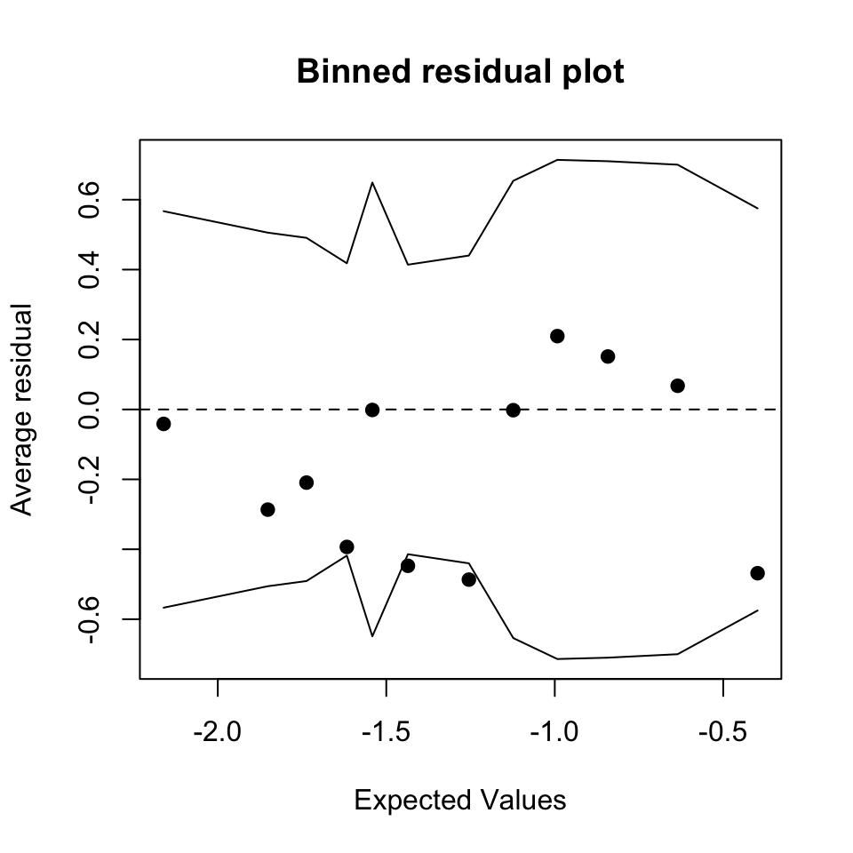

```r
binnedplot(predict(fm1), resid(fm1), cex.pts=1, col.int="black")
```

## 2. GLMM model of offspring recruitment status versus the P-distance PSS with total no. alleles as covariate and nest ID as random factor

```r
fm2 <- glmer(Recruitment~Nest+Total.no.alleles+PdistPSS+(1|Nest),family=binomial)
```

```
## singular fit
```

```r
summary(fm2)
```

```
## Generalized linear mixed model fit by maximum likelihood (Laplace
##   Approximation) [glmerMod]
##  Family: binomial  ( logit )
## Formula: Recruitment ~ Nest + Total.no.alleles + PdistPSS + (1 | Nest)
##
##      AIC      BIC   logLik deviance df.resid
##    158.5    173.4    -74.3    148.5      140
##
## Scaled residuals:
##     Min      1Q  Median      3Q     Max
## -1.0125 -0.5631 -0.4428 -0.3192  2.9424
##
## Random effects:
##  Groups Name        Variance Std.Dev.
##  Nest   (Intercept) 0        0
## Number of obs: 145, groups:  Nest, 34
##
## Fixed effects:
##                  Estimate Std. Error z value Pr(>|z|)
## (Intercept)      -0.58199    0.36922  -1.576   0.1150
## Nest             -0.04416    0.02184  -2.022   0.0432 *
## Total.no.alleles -0.14806    0.23602  -0.627   0.5305
## PdistPSS          0.21838    0.23584   0.926   0.3545
## ---
## Signif. codes:  0 '***' 0.001 '**' 0.01 '*' 0.05 '.' 0.1 ' ' 1
##
## Correlation of Fixed Effects:
##             (Intr) Nest   Ttl.n.
## Nest        -0.831
## Totl.n.llls  0.023  0.011
## PdistPSS    -0.058  0.010  0.523
## convergence code: 0
## singular fit
```

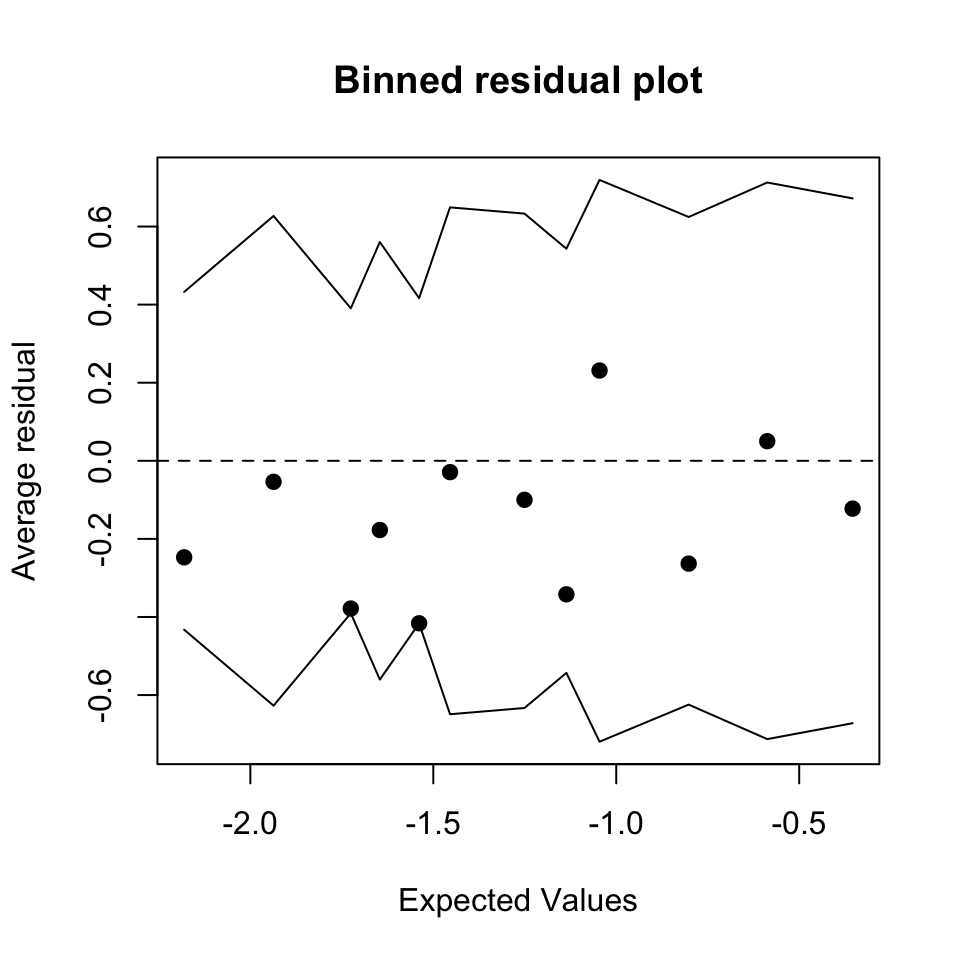

```r
binnedplot(predict(fm2), resid(fm2), cex.pts=1, col.int="black")
```

## 3. GLMM model of offspring recruitment status versus the P-distance PBR with total no. alleles as covariate, sex as a fixed factor, and nest ID as random factor

```r
fm3 <- glmer(Recruitment~Nest+Total.no.alleles+PdistPBR+Sex+Total.no.alleles:Sex+PdistPBR:Sex+(1|Nest),family=binomial)
```

```
## singular fit
```

```r
summary(fm3)
```

```
## Generalized linear mixed model fit by maximum likelihood (Laplace
##   Approximation) [glmerMod]
##  Family: binomial  ( logit )
## Formula:
## Recruitment ~ Nest + Total.no.alleles + PdistPBR + Sex + Total.no.alleles:Sex +
##     PdistPBR:Sex + (1 | Nest)
##
##      AIC      BIC   logLik deviance df.resid
##    163.5    187.3    -73.8    147.5      137
##
## Scaled residuals:
##     Min      1Q  Median      3Q     Max
## -1.1101 -0.5431 -0.4505 -0.3267  3.0210
##
## Random effects:
##  Groups Name        Variance Std.Dev.
##  Nest   (Intercept) 0        0
## Number of obs: 145, groups:  Nest, 34
##
## Fixed effects:
##                      Estimate Std. Error z value Pr(>|z|)
## (Intercept)           0.11252    0.71719   0.157    0.875
## Nest                 -0.04529    0.02194  -2.064    0.039 *
## Total.no.alleles     -0.36193    0.73636  -0.492    0.623
## PdistPBR              0.27721    0.73005   0.380    0.704
## Sex                  -0.48833    0.42947  -1.137    0.256
## Total.no.alleles:Sex  0.11392    0.51600   0.221    0.825
## PdistPBR:Sex         -0.15047    0.52319  -0.288    0.774
## ---
## Signif. codes:  0 '***' 0.001 '**' 0.01 '*' 0.05 '.' 0.1 ' ' 1
##
## Correlation of Fixed Effects:
##             (Intr) Nest   Ttl.n. PdsPBR Sex    Tt..:S
## Nest        -0.491
## Totl.n.llls  0.117 -0.092
## PdistPBR    -0.006 -0.064  0.547
## Sex         -0.855  0.072 -0.077  0.004
## Ttl.n.lll:S -0.109  0.101 -0.943 -0.529  0.072
## PdistPBR:Sx -0.029  0.074 -0.518 -0.943  0.031  0.562
## convergence code: 0
## singular fit
```

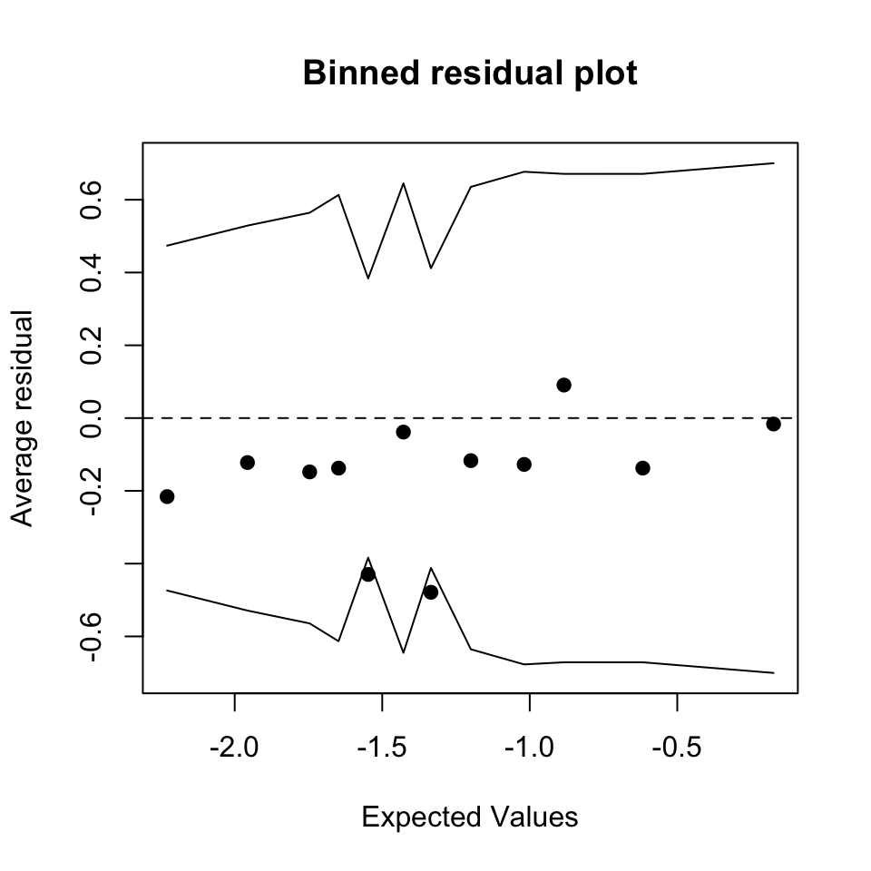

```r
binnedplot(predict(fm3), resid(fm3), cex.pts=1, col.int="black")
```

## 4. GLMM model of offspring recruitment status versus the P-distance PSS with total no. alleles as covariate, sex as a fixed factor, and nest ID as random factor

```r
fm4 <- glmer(Recruitment~Nest+Total.no.alleles+PdistPSS+Sex+Total.no.alleles:Sex+PdistPSS:Sex+(1|Nest),family=binomial)
```

```
## singular fit
```

```r
summary(fm4)
```

```
## Generalized linear mixed model fit by maximum likelihood (Laplace
##   Approximation) [glmerMod]
##  Family: binomial  ( logit )
## Formula:
## Recruitment ~ Nest + Total.no.alleles + PdistPSS + Sex + Total.no.alleles:Sex +
##     PdistPSS:Sex + (1 | Nest)
##
##      AIC      BIC   logLik deviance df.resid
##    162.9    186.7    -73.5    146.9      137
##
## Scaled residuals:
##     Min      1Q  Median      3Q     Max
## -1.1370 -0.5422 -0.4522 -0.2866  2.6490
##
## Random effects:
##  Groups Name        Variance Std.Dev.
##  Nest   (Intercept) 0        0
## Number of obs: 145, groups:  Nest, 34
##
## Fixed effects:
##                       Estimate Std. Error z value Pr(>|z|)
## (Intercept)           0.096661   0.718282   0.135    0.893
## Nest                 -0.044211   0.022051  -2.005    0.045 *
## Total.no.alleles     -0.480208   0.721181  -0.666    0.505
## PdistPSS             -0.008826   0.722379  -0.012    0.990
## Sex                  -0.487721   0.430271  -1.134    0.257
## Total.no.alleles:Sex  0.250167   0.499615   0.501    0.617
## PdistPSS:Sex          0.162552   0.546985   0.297    0.766
## ---
## Signif. codes:  0 '***' 0.001 '**' 0.01 '*' 0.05 '.' 0.1 ' ' 1
##
## Correlation of Fixed Effects:
##             (Intr) Nest   Ttl.n. PdsPSS Sex    Tt..:S
## Nest        -0.494
## Totl.n.llls  0.111 -0.116
## PdistPSS    -0.016 -0.115  0.526
## Sex         -0.854  0.072 -0.041  0.073
## Ttl.n.lll:S -0.090  0.124 -0.944 -0.523  0.015
## PdistPSS:Sx  0.006  0.118 -0.479 -0.946 -0.072  0.534
## convergence code: 0
## singular fit
```

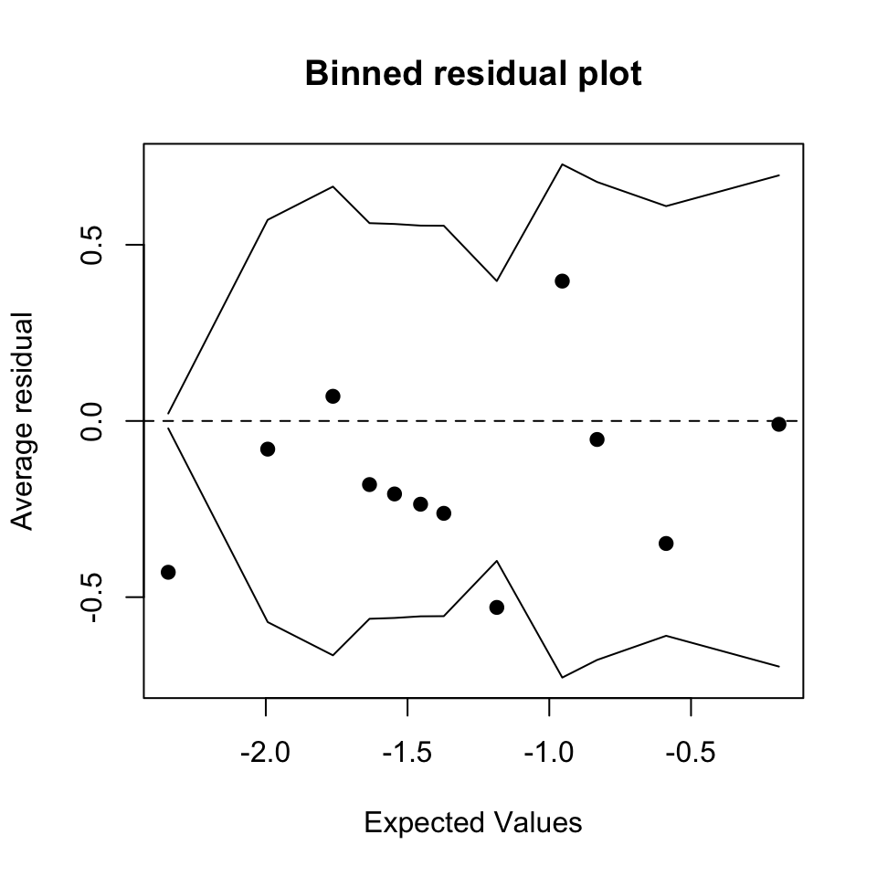

```r
binnedplot(predict(fm4), resid(fm4), cex.pts=1, col.int="black")
```